# Analysis of River Data Set

August 2018

# About the Data We’ll Use

This presentation will represent a replication of some analysis done in the article [*Control factors and scale analysis of annual river water, sediments and carbon transport in China*](http://www.nature.com/articles/srep25963). The data are available to download there but we will link to in on the gitHub web site for this course. A description of the variables is available at http://www.nature.com/articles/srep25963/tables/1.

# About the Analysis We’ll Look At

## Numerical Summaries

- Rc (Runoff coefficient - runoff depth divided by annual rainfall RD/total rainfall)
- TSSC_mgPl (Total suspended sediment concentration (mg/L) - average total suspended sediment concentration in the runoff)

Means will be found at **each** level of a new *size* variable. The variable is created using the `Size_km2` (watershed, catchment or basin area in km<sup>2</sup>) variable as described in the table below.

| Size in km<sup>2</sup> | Size Classification |
| --- | --- |
| < 15000 | ‘Small’ |
| < 100,000 | ‘Medium’ |
| < 350,000 | ‘Sizeable’ |
| < 700,000 | ’Large’ |
| >= 700,000 | ‘Great’ |

## Graphical Summaries

Graphs will be made to visualize the data as well.

1. Boxplots
2. Histograms
3. Scatter Plots

# Reading in Data

We’ll load the `readr` package to read in the data.

To create the new size variable we’ll use the `ifelse` command and `dplyr` functions. Then we’ll order the levels for plotting purposes.

```r
library(dplyr)
riverData <- riverData %>%
    mutate(Size = ifelse(Size_km2 < 15000, "Small",
                                             ifelse(Size_km2 < 100000, "Medium",
                                                         ifelse(Size_km2 < 350000, "Sizeable",
                                                                     ifelse(Size_km2 < 700000, "Large", "Great")))))

riverData$Size <- ordered(riverData$Size, levels = c("Small", "Medium", "Sizeable", "Large", "Great"))
```

```r
riverData <- riverData %>%
    mutate(MAT_Class = ifelse(MAP < 600, "Semiarid",
                                                        ifelse(MAP >= 600 & MAP < 850, "Moist",
                                                                     ifelse(MAP >= 850 & MAP < 1500, "Humid", "Wet"))))

riverData$MAT_Class <- ordered(riverData$MAT_Class, levels = c("Semiarid", "Moist", "Humid", "Wet"))
```

# Analysis Part I

## The Rc Variable

```r
riverData %>% group_by(Size) %>% summarise(mean(Rc, na.rm = TRUE))
riverData %>% group_by(Size) %>% summarise(count = sum(!is.na(Rc)))
riverData %>% group_by(Size) %>% summarise(var = var(Rc, na.rm = TRUE))
```

[output not shown]

## The TSSC Variable

The means, counts, and standard deviations for each level of Size are given below.

```r
riverData %>% group_by(Size) %>% summarise(mean(TSSC_mgPl, na.rm = TRUE))
```

```
## # A tibble: 5 x 2
##   Size     `mean(TSSC_mgPl, na.rm = TRUE)`
##   <ord>                              <dbl>
## 1 Small                              3239.
## 2 Medium                             3169.
## 3 Sizeable                            819.
## 4 Large                              1523.
## 5 Great                              3430.
```

```r
riverData %>% group_by(Size) %>% summarise(count = sum(!is.na(TSSC_mgPl)))
```

```
## # A tibble: 5 x 2
##   Size     count
##   <ord>    <int>
## 1 Small       33
## 2 Medium      59
## 3 Sizeable    52
## 4 Large       59
## 5 Great       55
```

```r
riverData %>% group_by(Size) %>% summarise(sd = sd(TSSC_mgPl, na.rm = TRUE))
```

```
## # A tibble: 5 x 2
##   Size         sd
##   <ord>     <dbl>
## 1 Small     6816.
## 2 Medium   13658.
## 3 Sizeable   765.
## 4 Large     4033.
## 5 Great     5654.
```

# Analysis Part II

## Boxplots

The `ggplot2` package will be used to create some fun plots to visualize the data. First, a boxplot of the Rc variable for each level of Size where the means of each group are connected.

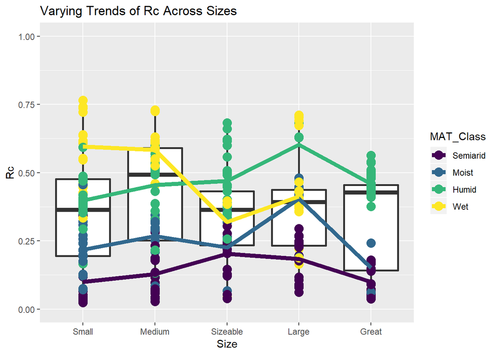

```r
library(ggplot2)
g <- ggplot(data = riverData, aes(x = Size, y = Rc))
g + geom_boxplot(lwd = 1) +
    coord_cartesian(ylim = c(0, 1)) +
    labs(title = "Varying Trends of Rc Across Sizes", x = "Size") +
    geom_point(aes(col = MAT_Class), size = 4) +
    stat_summary(fun.y = mean, geom = "line", lwd = 2, aes(group = MAT_Class, col = MAT_Class))
```

## Histograms

Histograms of the Rc variable for each setting of Size are given below.

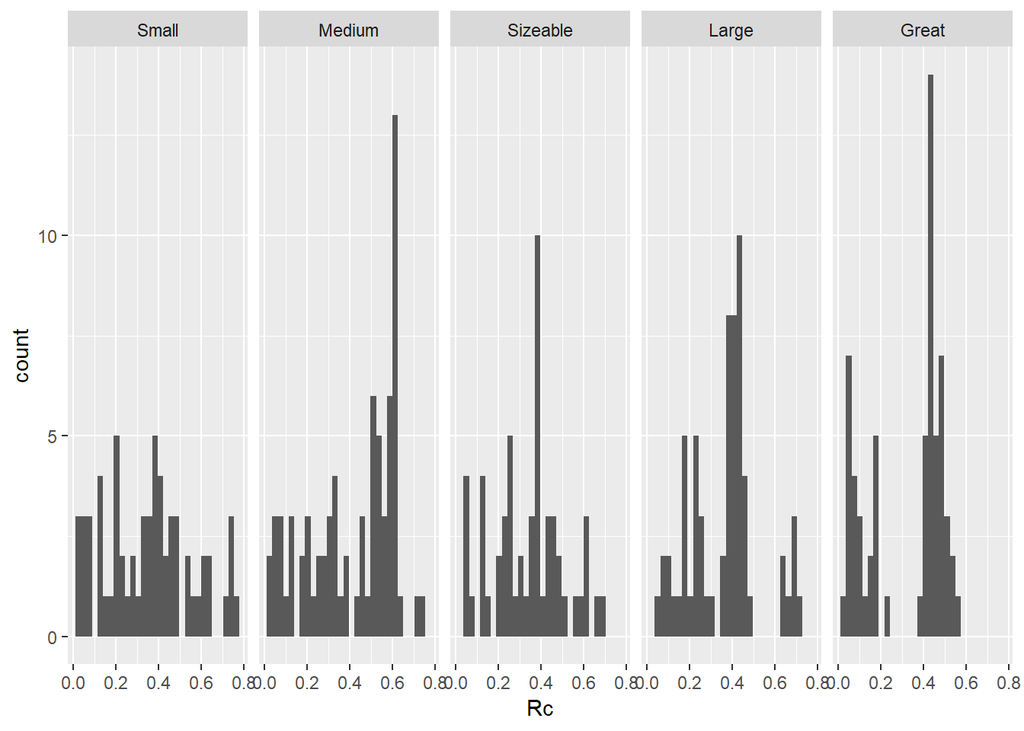

```r
g <- ggplot(data = riverData, aes(x = Rc))
g + geom_histogram() +
    facet_grid(. ~ Size)
```

## Scatter Plots

Lastly, scatter plots of the Rc variable and the TSSC variable are made *for each* combination of the Size and MAT_Class variables.

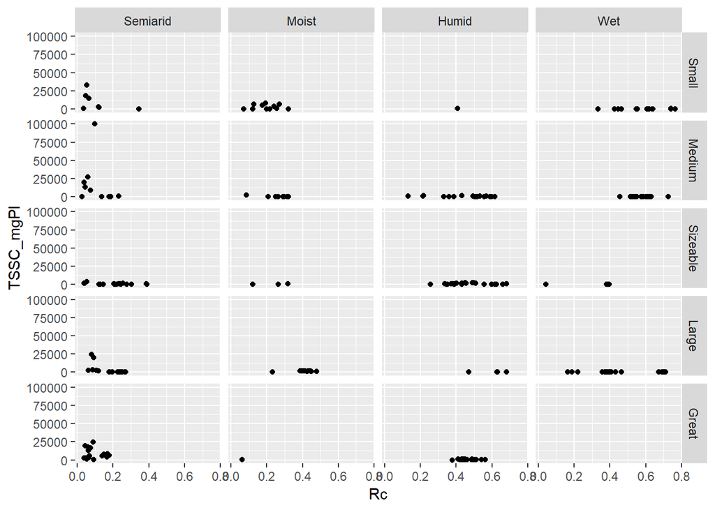

```r
g <- ggplot(data = riverData, aes(x = Rc, y = TSSC_mgPl))
g + geom_point() +
    facet_grid(Size ~ MAT_Class)
```